# Dispersion

## Phonon dispersion

The program supports the calculation of the effects of phonon dispersion on thermodynamic properties. The required input data can be obtained by any program like [CRYSTAL17](https://www.crystal.unito.it) implementing a supercell approach to get vibrational frequencies of the off-center modes.

The example below refers to the case of the $\alpha$-quartz, for which phonon frequencies were computed for a 2x2x2 supercell: in addition to the frequencies at the center of the Brillouin zone (BZ), 7 other sets of frequencies were obtained corresponding to the (0 0 1/2), (0 1/2 0), (1/2 0 0), (0 1/2 1/2), (1/2 0 1/2), (1/2 1/2 0) and (1/2 1/2 1/2) K-points of the BZ (the *DISPERSI* keyword was specified in the CRYSTAL input file). Supercell frequencies were computed for several values of the unit cell volume.

In order to require phonon dispersion correction, the keyword **DISP** must be present in the input file *input.txt*; such keyword must be followed by the names of two files containing the relevant data. In the present case:

```
DISP
quartz_disp.dat
quartz_disp_info.dat
```

The file *quartz_disp.dat* contains the set of frequencies, each column referring to a specific unit cell volume; the first column of the file does contain the degeneracy of each mode. Along each column, the frequencies are ordered according to the following hierarchy:

1. the frequencies of the modes belonging to each one of the K-points of the BZ, that is, the (0 0 1/2) modes first, then the (0 1/2 0) modes... and, lastly, the (1/2 1/2 1/2) modes
2. the symmetry of the modes
3. the value of frequencies: that is, within each group of modes belonging to the same K-point and having the same symmetry, frequencies are sorted according to their value.

In this way, all the frequencies along a given row of the input file refer to the same mode, as it changes as a function of volume. The example below is a section of the *quartz_disp.dat*, where the frequencies of the (0 0 1/2) K-point are shown, calculated for three different values of the unit cell volume:

```
 1   209.578          211.24       210.95
 1   401.8457         387.08       395.83
 1   790.0472         776.39       783.82
 1   1120.1813        1128.20      1124.21
 1   56.7594          47.51        53.18
 1   171.7892         181.46       175.85
 1   393.5102         372.92       385.14
 1   779.9419         762.05       772.48
 1   1061.4419        1055.16      1059.07
 2   130.2962         105.66       121.46
 2   188.5704         193.30       190.35
 2   263.4401         247.93       257.05
 2   428.0019         422.10       426.00
 2   458.9878         452.47       455.91
 2   580.3685         563.36       574.12
 2   794.6851         776.13       786.05
 2   1080.7245        1074.68      1078.27
 2   1222.3513        1222.03      1222.12
```

The file *quartz_disp_info.dat* contains information about the *structure* of the *quartz_disp.dat* file, which are required by the program to correctly interpret the data. The file in this example is:

```
7 3 5. 1200.
18 27 27 27 27 27 27
1  1  1  1  1  1  1
114.860943   121.000435  117.551141 ...
```

We have four rows whose content is:

- first row:
  1. the number of K-points (7);
  2. the degree of the polynomial fitting the frequencies as function of the unit cell volume (3);
  3. if greater than 0., a spline fitting is requested (instead of a polynomial fit of the same degree) with the specified *smooth* parameter (5)
  4. maximum temperature for the *F(V,T)* fit of the Helmholtz function (see below)
- second row: the number of frequencies listed for *each* K-point
- third row: the *weight* of each K-point (the multiplicity of the K-point according to the symmetry of the system)
- fourth row: the unit cell volumes (here, only three volumes are specified)

Notes:

- The order of the unit cell volumes in the fourth row of the *info* file must correspond to the order of the columns of frequencies' file.
- A volume-temperature grid is built: the volume axis is defined by the volumes specified in input; the temperature axis is defined up to the maximum temperature specified (first row, fourth parameter of the *info* file). For each point of the grid, the Helmholtz *F* function is computed; the set of values are then fitted by a power series up to an order specified within the program (default value: 4). The resulting *F(V,T)* function is then used to compute the contribution of the off-center modes to the total Helmholtz function at any volume and temperature.

Having prepared all of the required input, the program is here started:

```
This is BMx-QM program, version 2.4.0 - 18/02/2021
Run time:  2021-05-14 17:18:57.783259

File quick_start.txt found in the master folder
Input files in 'quarzo_2020' folder

Input file

TITLE
Quartz 2020
STATIC
static.dat
VOLUME
volumes.dat
FREQ
frequencies.dat
FITVOL
POLY
92. 126. 16 3
SET
0 1 2 3 4 5 6 7 8 9 10 11
FU
3 3
LO
LO.txt
DISP
quartz_disp.dat
quartz_disp_info.dat
END

-------- End of input file -------

Phonon dispersion correction activated by the DISP keyword
in the input file; the contribution to the entropy and to the
specific heat is taken into account.


Warning ** Volume and frequencies lists have been sorted
           indexing:  [ 0  1  2  3 11  8 10  4  9  5  6  7]

```

[output cut: 8 more lines]

```


Instructions from quick_start file will be executed:

disp.free_fit_ctrl(degree=6)
disp.eos_on()
volume_ctrl.set_all(degree=2, upgrade_shift=True, quad_shrink=8)
--------------------------------------------------


disp.free_fit_ctrl(degree=6)
V,T-fit of the Helmholtz free energy contribution from the off-centered modes
Power of the fit:   6
Mean error: 1.06e-04
Maximum error: 3.59e-04
```

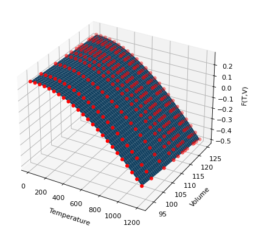

```
disp.eos_on()
Phonon dispersion correction for bulk_dir computation


volume_ctrl.set_all(degree=2, upgrade_shift=True, quad_shrink=8)
```

```python
%matplotlib inline
%run bm3_thermal_2
```

Note the following commands:

```
disp.free_fit_ctrl(degree=6)
```

This command invokes a method of the *disp* class: *free_fit_ctrl* that, in the present case, sets to 6 the degree of the *F(V,T)* power series.

```
disp.eos_on()
```

It requests the computation of *F(V,T)* function (power series up to the 6-th degree as specified above).

```
volume_ctrl.set_all(degree=2, upgrade_shift=True, quad_shrink=8)
```

It invokes a *volume driver* that sets appropriate numerical parameters for the calculation of the volume at given temperature and pressure, (un)compressibilities and thermal expansion, in a *direct* way, *without* the recourse to any equation of state.

For more, see the help on the volume_control_class in the [index](https://qm-thermodynamics.readthedocs.io/en/main/genindex.html) section of this site.

As an example, we calculate here the bulk modulus $K$ as a function of temperature in the range $[50, 700K]$ (24 *T* values in the range), at the zero pressure. The calculation is performed according to the definition

$$K = -V\left(\frac{\partial P}{\partial V}\right)_T$$

where *P(V)*, at any given *T*, is *directly* computed as

$$P=-\left(\frac{\partial F}{\partial V}\right)_T$$

To the purpose, the function bulk_modulus_p_serie is used

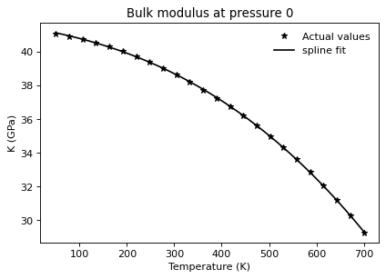

```python
bulk_modulus_p_serie(50, 700, 24, 0, noeos=True, fit=True, type='spline', deg=3, smooth=2)
```

To compute the bulk modulus at a given temperature, from an EoS fit (3-th order Birch-Murnaghan EoS), the function bulk_dir can be used:

```
BM3 EoS from P(V) fit

K0:     40.37   (0.14) GPa
Kp:      5.00   (0.02)
V0:  116.2296   (0.02) A^3
```

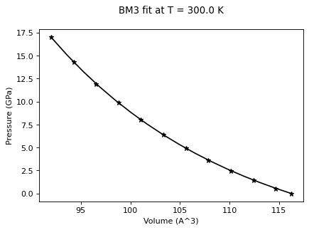

```python
bulk_dir(300)
```

Above, the computation was done with the phonon dispersion effects included. We can now switch off the phonon dispersion correction and recompute the fit:

```
No phonon dispersion correction for bulk_dir computation

BM3 EoS from P(V) fit

K0:     38.79   (0.23) GPa
Kp:      5.18   (0.04)
V0:  116.4281   (0.03) A^3
```

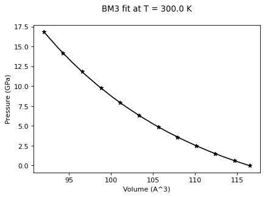

```python
disp.eos_off()
bulk_dir(300)
```

In this case, the phonon dispersion had a relatively small impact on the computed bulk modulus $K_0$ at T=300 K.

Entropy and specific heat are particularly sensitive to phonon dispersion effects. With dispersion included:

```python
entropy_p(298,0)
cp(298,0,prt=True)
```

```
Entropy:   39.63 J/mol K
Specific heat (at constant volume):   41.80 J/mol K
Pressure:  0.00 GPa; Volume 116.6736 A^3

Cp:  42.22, Cv:  41.80, Cp/Cv: 1.01016, alpha: 4.080e-05, K:  36.57
```

With no dispersion:

```python
disp.off()
entropy_p(298,0)
cp(298,0, prt=True)
```

```
Dispersion correction off

Entropy:   27.11 J/mol K
Specific heat (at constant volume):   35.50 J/mol K
Pressure:  0.00 GPa; Volume 116.6736 A^3

Cp:  35.92, Cv:  35.50, Cp/Cv: 1.01197, alpha: 4.080e-05, K:  36.57
```

The computation with dispersion included agrees with the experimental data by [Richet et al. (1982)](https://www.sciencedirect.com/science/article/abs/pii/0016703782903830)